# Syntaxe du calcul propositionnel

On dispose d'un alphabet constitué :

- d'un ensemble $\mathcal{V}$ appelé ensemble des variables propositionnelles ;
- de deux constantes $\top$ et $\bot$ ;
- d'un connecteur unaire $\neg$ ; on dira aussi que $\neg$ est un connecteur logique d'arité 1 ;
- des connecteurs binaires (i.e d'arité 2) $\wedge$, $\vee$, $\rightarrow$ et $\leftrightarrow$.

L'ensemble $\mathcal{F}$ des formules du calcul propositionnel, ou formules logiques, est le plus petit ensemble tel que :

- $\top$ et $\bot$ sont des formules logiques
- Les variables propositionnelles (i.e les éléments de $\mathcal{V}$) sont des formules logiques.
- Si $\varphi$ est une proposition alors $(\neg \varphi)$ est une proposition.
- Si $\varphi$ et $\psi$ sont deux formules, alors
  - $(\varphi \wedge \psi)$ est une proposition logique.
  - $(\varphi \vee \psi)$ est une proposition logique.
  - $(\varphi \rightarrow \psi)$ est une proposition logique.
  - $(\varphi \leftrightarrow \psi)$ est une proposition logique.

Par exemple, si $p,q,r$ sont des variables propositionnelles alors : $p$ ; $(p \vee (q \rightarrow r))$ ; $\neg( ( q \vee (p \leftrightarrow (\neg r))) \wedge p ) $ sont des formules logiques.

En revanche $p \neg q \wedge \vee r$ n'est pas une formule logique.

Une formule logique peut se représenter sous forme d'un arbre. Par exemple, $(q \vee (p \leftrightarrow (\neg r))) \wedge (\neg (q \rightarrow r)) $ est représenté par :

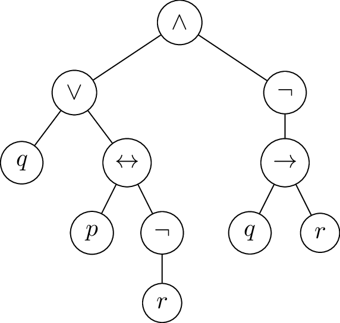

La *hauteur* d'une formule est la hauteur de l'arbre correspondant. La *taille* de la formule est le nombre de symbole qu'elle contient.

Enfin, une *sous-formule* d'une formule $\varphi$ représentée par un arbre $A$ est une formule dont l'arbre est un sous-arbre de $A$.

Par exemple, $p \leftrightarrow (\neg r)$ est une sous-formule de $(q \vee (p \leftrightarrow (\neg r))) \wedge (\neg (q \rightarrow r)) $

L'ensemble $\mathcal{V}$ étant fixé, pour démontrer une propriété $P$ sur les formules, on pourra raisonner

- par récurrence sur la hauteur ou sur la taille des formules
- par **induction structurelle**, en montrant que
  - la propriété $P$ est vérifiée par $\top$, $\bot$ et par les éléments de $\mathcal{V}$
  - Si $P$ est vérifiée par $\varphi$ alors $P$ est vérifiée par $\neg \varphi$
  - Si $P$ est vérifiée par $\varphi_1$ et $\varphi_2$, alors $P$ est vérifiée par $\varphi_1 \vee \varphi_2$, par $\varphi_1 \wedge \varphi_2$, par $\varphi_1 \rightarrow \varphi_2$ et par $\varphi_1 \leftrightarrow \varphi_2$.

# Sémantique du calcul propositionnel

## Évaluation d'une proposition logique

On considère l'ensemble $\{V,F\}$ des valeurs de vérité.

Une *valuation* est une application de l'ensemble $\mathcal{V}$ des variables propositionnelles dans $\{V,F\}$ : à chaque variable propositionnelle, on associe une valeur de vérité.

Si $\sigma$ est une valuation, on définit inductivement l'évaluation $v_{\sigma}(\varphi)$ d'une proposition $\varphi$ pour la valuation $\sigma$ par :

- $v_{\sigma}(\top)=V$ et $v_{\sigma}(\bot)=F$.
- Si $\varphi=v \in \mathcal{V}$, alors $v_{\sigma}(\varphi)=\sigma(v)$
- Si $\varphi= \neg \psi$, alors $\displaystyle v_{\sigma}(\varphi)= \left\lbrace\begin{array}{ll} F, & \text{ si } v_{\sigma}(\psi) = V \\ V, & \text{ sinon } \end{array}\right.$
- Si $\varphi =\varphi_1 \wedge \varphi_2$, alors $\displaystyle v_{\sigma}(\varphi)= \left\lbrace\begin{array}{ll} V, & \text{ si } v_{\sigma}(\varphi_1) = V \text{ et } v_{\sigma}(\varphi_2) = V \\ F, & \text{ sinon } \end{array}\right.$
- Si $\varphi =\varphi_1 \vee \varphi_2$, alors $\displaystyle v_{\sigma}(\varphi)= \left\lbrace\begin{array}{ll} V, & \text{ si } v_{\sigma}(\varphi_1) = V \text{ ou } v_{\sigma}(\varphi_2) = V \\ F, & \text{ sinon } \end{array}\right.$
- Si $\varphi =\varphi_1 \rightarrow \varphi_2$, alors $\displaystyle v_{\sigma}(\varphi)= \left\lbrace\begin{array}{ll} F, & \text{ si } v_{\sigma}(\varphi_1) = V \text{ et } v_{\sigma}(\varphi_2) = F \\ V, & \text{ sinon } \end{array}\right.$
- Si $\varphi =\varphi_1 \leftrightarrow \varphi_2$, alors $\displaystyle v_{\sigma}(\varphi)= \left\lbrace\begin{array}{ll} V, & \text{ si } v_{\sigma}(\varphi_1) = v_{\sigma}(\varphi_2)\\ F, & \text{ sinon } \end{array}\right.$

## Table de vérité

Si une proposition $\varphi$ s'exprime à l'aide de $n$ variables propositionnelles $(v_1,\dots,v_n)$, il y a $2^n$ valeurs possibles pour le n-uplet $(\sigma(v_1),\dots,\sigma(v_n))$.

On peut alors résumer l'évaluation de $\varphi$ en fonction des valeurs de ses variables dans une table de vérité à $2^n$ lignes.

Par exemple, soit $\varphi= p \vee (\neg p \wedge q)$. Sa table de vérité est :

| $p$ | $q$ | $\neg p$ | $\neg p \wedge q$ | $\varphi$ |
| --- | --- | --- | --- | --- |
| $\text{V}$ | $\text{V}$ | $\text{F}$ | $\text{F}$ | $\text{V}$ |
| $\text{V}$ | $\text{F}$ | $\text{F}$ | $\text{F}$ | $\text{V}$ |
| $\text{F}$ | $\text{V}$ | $\text{V}$ | $\text{V}$ | $\text{V}$ |
| $\text{F}$ | $\text{F}$ | $\text{V}$ | $\text{F}$ | $\text{F}$ |

## Tautologies et satisfiabilité

- On dit qu'une formule $\varphi$ est *satisfiable* lorsqu'il existe une valuation $\sigma$ telle que $v_{\sigma}(\varphi) = V$. On dit alors que $\sigma$ est un *modèle* pour $\varphi$.
- On dit qu'une formule $\varphi$ est une tautologie lorsque pour toute valuation $\sigma$, $v_{\sigma}(\varphi) = V$, autrement dit lorsque toutes les valuations sont des modèles pour $\varphi$.
- On dit qu'une formule $\varphi$ est une antologie lorsque pour toute valuation $\sigma$, $v_{\sigma}(\varphi) = F$, autrement dit lorsque $\varphi$ n'est pas satisfiable.

Par exemple, la formule $(p \Rightarrow q) \leftrightarrow (\neg p \vee q)$ est une tautologie ; en effet, la table de vérité associée à cette formule est :

| $p$ | $q$ | $p \Rightarrow q$ | $\neg p$ | $\neg p \vee q$ | $(p \rightarrow q) \leftrightarrow (\neg p \vee q)$ |
| --- | --- | --- | --- | --- | --- |
| $\text{V}$ | $\text{V}$ | $\text{V}$ | $\text{F}$ | $\text{V}$ | $\text{V}$ |
| $\text{V}$ | $\text{F}$ | $\text{F}$ | $\text{F}$ | $\text{F}$ | $\text{V}$ |
| $\text{F}$ | $\text{V}$ | $\text{V}$ | $\text{V}$ | $\text{V}$ | $\text{V}$ |
| $\text{F}$ | $\text{F}$ | $\text{V}$ | $\text{V}$ | $\text{V}$ | $\text{V}$ |

**Remarques :**

- Une formule $\varphi$ est satistiable si et seulement si l'ensemble de ses modèles est non vide.
- Une formule $\varphi$ est non satisfiable si et seulement si $\neg \varphi$ est une tautologie. £ Par conséquent, savoir tester si une formule est satisfiable et savoir tester si une formule est une tautologie sont des problèmes étroitement liés.
- On peut résoudre le problème de la satisfiabilité d'une formule $\varphi$ en construisant sa table de vérité et en examinant toutes les lignes. Si $\varphi$ comporte $n$ variables propositionnelles, le temps de calcul pour cette méthode est clairement proportionnelle à $2^n$ (on dira qu'on peut résoudre le problème en temps $O(2^n)$.
- En revanche, étant donnée une valuation $\sigma$, il est facile de vérifier si $v_{\sigma}(\varphi)=V$ (en temps polynomial). On ne connaît pas d'algorithme réellement plus performant ; ce problème fait partie d'une classe de problèmes d'optimisation difficiles.

## Formules logiquement équivalentes

- On dit que deux formules logiques $\varphi$ et $\psi$ sont *équivalentes*, et on note $\varphi \equiv \psi$, lorsque, pour toute valuation $\sigma$, $v_{\sigma}(\varphi) = v_{\sigma}(\psi)$.
- On dit que $\psi$ est une *conséquence logique* de $\varphi$, et on note $\varphi \models \psi$, lorsque tout modèle de $\varphi$ est un modèle de $\psi$, autrement dit lorsque pour toute valuation $\sigma$, si $v_{\sigma}(\varphi) = V$ alors $v_{\sigma}(\psi)=V$.

**Remarque :** La relation $\equiv$ est une relation d'équivalence.

Pour vérifier que deux formules sont logiquement équivalentes, on examine leurs tables de vérité. Par exemple, $p \vee (\neg p \wedge q) \equiv p\vee q$.

## Quelques équivalences fondamentales

Soient $\varphi_1$, $\varphi_2$ et $\varphi_3$ trois formules. Alors :

- $\varphi_1 \wedge \varphi_2 \equiv \varphi_2 \wedge \varphi_1$ et $\varphi_1 \vee \varphi_2 \equiv \varphi_2 \vee \varphi_1$ *(commutativité de $\wedge$ et de $\vee$)*.
- $(\varphi_1 \wedge \varphi_2) \wedge \varphi_3 \equiv \varphi_1 \wedge (\varphi_2 \wedge \varphi_3)$ et $(\varphi_1 \vee \varphi_2) \vee \varphi_3 \equiv \varphi_1 \vee (\varphi_2 \vee \varphi_3)$ *(associativité de $\wedge$ et de $\vee$)*.
- $(\varphi_1 \wedge \varphi_2) \vee \varphi_3 \equiv (\varphi_1 \vee \varphi_3)\wedge (\varphi_2 \vee \varphi_3)$ et $(\varphi_1 \vee \varphi_2) \wedge \varphi_3 \equiv (\varphi_1 \wedge \varphi_3)\vee (\varphi_2 \wedge \varphi_3)$ *(distributivité de $\vee$ par rapport à $\wedge$ et de $\wedge$ par rapport à $\vee$)*.

**Remarque :** l'associativité permettra de faire l'économie de quelques parenthèses : on notera $\varphi_1 \vee \varphi_2 \vee \dots \vee \varphi_3$ au lieu $((\dots (\varphi_1 \vee \varphi_2) \vee \dots) \vee \varphi_3)$ ; de même pour $\wedge$.

Soient $\varphi_1$, $\varphi_2$ deux formules. Alors :

- $\varphi_1 \vee (\varphi_1 \wedge \varphi_2) \equiv \varphi_1$
- $\varphi_1 \wedge (\varphi_1 \vee \varphi_2) \equiv \varphi_1$
- **Lois de Morgan** : $\neg (\varphi_1 \vee \varphi_2) \equiv (\neg \varphi_1) \wedge (\neg \varphi_2)$ et $\neg (\varphi_1 \wedge \varphi_2) \equiv (\neg \varphi_1) \vee (\neg \varphi_2)$
- **Tiers-exclu** : $\varphi_1 \vee \neg \varphi_1 \equiv \top$, autrement dit $\varphi_1 \vee \neg \varphi_1$ est une tautologie
- **Décomposition de l'implication** : $\varphi_1 \rightarrow \varphi_2 \equiv (\neg \varphi_1) \vee \varphi_2$
- **Décomposition de l'équivalence** : $\varphi_1 \leftrightarrow \varphi_2 \equiv (\varphi_1 \rightarrow \varphi_2) \wedge (\varphi_2 \rightarrow \varphi_1)$
- **Contraposition** : $(\varphi_1 \rightarrow \varphi_2) \equiv (\neg \varphi_2 \rightarrow \neg \varphi_1)$

## Ensemble de formules

On peut généraliser les définitions à un ensemble $\Gamma$ de formules :

- Un *modèle* pour un ensemble de formules $\Gamma$ est une valuation $\sigma$ telle que $$\forall \varphi \in \Gamma,\ v_{\sigma}(\varphi) = V$$
- Une formule $\psi$ est une *conséquence logique* de $\Gamma$ lorsque tout modèle de $\Gamma$ est un modèle de $\psi$. On note alors $\Gamma \models \psi$.

Par exemple, $\{p, p \rightarrow q\} \models q$.

# Formes normales

*Définitions*

- On appelle *littéral* toute proposition logique de la forme $v$ ou $\neg v$, où $v$ est une variable propositionnelle.
- Une *conjonction élémentaire* est une forme de la forme $l_1 \wedge l_2 \wedge \dots \wedge l_{n-1} \wedge l_n$ où chaque $l_i$ est un littéral (ou de la forme $\top$).
- Une *clause*, ou *disjonction élémentaire*, est une formule de la forme $l_1 \vee l_2 \vee \dots \vee l_{m-1} \vee l_m$ où chaque $l_i$ est un littéral (ou de la forme $\bot$).

*Définitions*

- Une proposition $\varphi$ est dite sous forme normale disjonctive si elle est de la forme $C_1 \vee C_2 \vee \dots \vee C_k$ où chaque $C_i$ est une conjonction élémentaire. $$\varphi = \bigvee_{i} \left( \bigwedge_{j} l_{i,j} \right)$$
- Une proposition $\varphi$ est dite sous forme normale conjonctive si elle est de la forme $D_1 \wedge D_2 \wedge \dots \wedge D_q$ où chaque $D_i$ est une clause. $$\varphi = \bigwedge_{i} \left( \bigvee_{j} l_{i,j} \right)$$

**Proposition** :

- Si $\varphi$ est une conjonction alors $\neg \varphi$ est équivalente à une disjonction.
- Si $\varphi$ est une disjonction alors $\neg \varphi$ est équivalente à une conjonction.

**Théorème** : Soit $\varphi$ une formule logique quelconque. Alors

- il existe une formule logique $\varphi'$ sous forme normale disjonctive logiquement équivalente à $\varphi$.
- il existe une formule logique $\varphi''$ sous forme normale conjonctive logiquement équivalente à $\varphi$.

## Table de vérités et forme normale disjonctive

**Lemme** :Soient $v_1,\dots,v_n$ des variables propositionnelles et $\sigma$ une valuation sur $\{v_1,\dots,v_n\}$. On pose $l_i = v_i$ si $\sigma(v_i)=1$ et $l_i = \neg v_i$ si $\sigma(v_i)=0$. Soit $C_\sigma = l_1 \wedge \dots \wedge l_n$.\ Alors pour toute valuation $\tau$, $\displaystyle V_\tau (C_\sigma) = \left\lbrace\begin{array}{ll} 1 & \text{ si } \tau = \sigma \\ 0 & \text{ sinon} \end{array} \right.$

Soit $\varphi= (p\vee (\neg q))\wedge (q \leftrightarrow (\neg p \vee r))$. Sa table de vérité est :

| $p$ | $q$ | $r$ | $p\vee (\neg q)$ | $\neg p \vee r$ | $q \leftrightarrow (\neg p \vee r)$ | $\varphi$ |
| --- | --- | --- | --- | --- | --- | --- |
| $\text{V}$ | $\text{V}$ | $\text{V}$ | $\text{V}$ | $\text{V}$ | $\text{V}$ | $\text{V}$ |
| $\text{V}$ | $\text{V}$ | $\text{F}$ | $\text{V}$ | $\text{F}$ | $\text{F}$ | $\text{F}$ |
| $\text{V}$ | $\text{F}$ | $\text{V}$ | $\text{V}$ | $\text{V}$ | $\text{F}$ | $\text{F}$ |
| $\text{V}$ | $\text{F}$ | $\text{F}$ | $\text{V}$ | $\text{F}$ | $\text{V}$ | $\text{V}$ |
| $\text{F}$ | $\text{V}$ | $\text{V}$ | $\text{F}$ | $\text{V}$ | $\text{V}$ | $\text{F}$ |
| $\text{F}$ | $\text{V}$ | $\text{F}$ | $\text{F}$ | $\text{V}$ | $\text{V}$ | $\text{F}$ |
| $\text{F}$ | $\text{F}$ | $\text{V}$ | $\text{V}$ | $\text{V}$ | $\text{F}$ | $\text{F}$ |
| $\text{F}$ | $\text{F}$ | $\text{F}$ | $\text{V}$ | $\text{V}$ | $\text{F}$ | $\text{F}$ |

Donc $\varphi \equiv (p \wedge q \wedge r) \vee (p \wedge \neg q \wedge \neg r) $

## Problème SAT

Le problème SAT est le problème consistant à déterminer si une formule propositionnelle est satisfiable. Pour une formule propositionnelle comportant $n$ variables, on peut toujours répondre à ce problème en examinant les $2^n$ valuations possibles, ce qui donne un algorithme exponentiel.

Par ailleurs, pour un entier non nul $k$ fixé, le problème $k$-SAT consiste à déterminer si une formule $\varphi$ sous forme normale conjonctive dont chaque clause comporte $k$ littéraux est satisfiable.

Le problème $1$-SAT peut se résoudre en temps linéaire : une instance $\varphi$ de $1$-SAT est satisfiable si et seulement si $\varphi$ ne contient pas à la fois une variable et sa négation.

Le problème $2$-SAT peut se résoudre grâce à un graphe. On construit un graphe orienté dont les sommets sont étiquetés par les variables propositions et leur négation. Comme toute clause $\ell_1 \vee \ell_2$ est équivalente à $(\neg \ell_1 \rightarrow \ell_2) \wedge (\neg \ell_2 \rightarrow \ell_1)$, on construit une arête de $\neg \ell_1 $ vers $\ell_2$ et de $\neg \ell_2$ vers $\ell_1$.

On peut alors montrer qu"une instance de $2$-SAT est satisfiable si et seulement si aucune composante fortement connexe du graphe ne contient à la fois une variable propositionnelle et sa négation, et qu'il est possible de le vérifier en temps polynomial.

Tout instance de $k$-SAT pour $k \geqslant 3$ peut se réduire à une instance de $3$-SAT en ajoutant des variables propositionnelles.

On ne connaît aucun algorithme polynomial pour résoudre $3$-SAT.